# Led Zeppelin Data Analysis

Aidan Kay

As a longtime fan on the famous hard rock band Led Zeppelin, I have always thought that the sound of the group has changed greatly from album to album. For instance, certain albums stuck more to the roots of rock music with many popular rock radio hits, while others had more drawn out instrumentals, such as guitar and drum solos. Additionally, many of their records featured a significant portion of songs that were heavily influenced by folk and classic blues music.

To see if my assumptions are statistically supported, I will be making exploratory plots and statistical inferences on the eight studio albums of the band based on the track by track data obtained from Spotify. First I will look at `acousticness`, then I will look at `instrumentalness` as measures of overall sound.

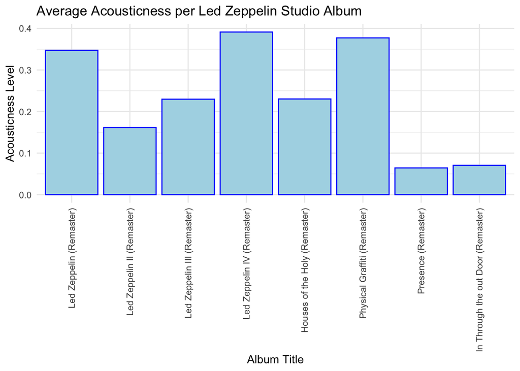

```r
zeppelin0 <- zeppelin %>%
  filter(endsWith(album_name, "(Remaster)")) %>%
  filter(album_release_year < 1980,
         album_name != "The Song Remains the Same (Remaster)") %>%
  group_by(album_name)

zeppelin1 <- zeppelin0 %>%
  summarize(avg_ac = mean(acousticness))

zeppelin1$album_name <- fct_relevel(zeppelin1$album_name, "Led Zeppelin (Remaster)" , "Led Zeppelin II (Remaster)", "Led Zeppelin III (Remaster)",
              "Led Zeppelin IV (Remaster)", "Houses of the Holy (Remaster)", "Physical Graffiti (Remaster)",
              "Presence (Remaster)", "In Through the out Door (Remaster)")


ggplot(zeppelin1, aes(x = album_name, y = avg_ac)) +
  geom_col(fill = 'lightblue', color = 'blue') + theme_minimal() +
  theme(axis.text.x = element_text(angle = 90, vjust = 0.5, hjust=1)) +
  labs(title = 'Average Acousticness per Led Zeppelin Studio Album', x = 'Album Title', y= 'Acousticness Level')
```

Above is a bar chart displaying the average acousticness of each Led Zeppelin record ordered by the year of their release.

`acousticness` is the measure of how acoustic (opposed to electric) a song is, and a score of 1.0 means that the song is acoustic[^1].

We see that overall their music was never entirely acoustic, but there is seemingly a change in acousticness album to album. The overall trends here do make sense to me. Their first album definitely incorporated significant blues and folk elements, then they went on to record hard rock oriented music, with some return to the folk elements towards the middle of their career. Then, the final couple albums featured more electronic and keyboard elements, so it makes sense to me that these scored relatively low acousticness.

Now, I will run an Anova test to see if we can reasonably infer that there is indeed a difference in acousticness based on the album.

Null Hypothesis: Acousticness remains the same across Led Zeppelin’s studio albums.

Alternative Hypothesis: Acousticness differs between Led Zeppelin’s studio albums.

```r
model <- aov(acousticness ~ album_name,
                  data = zeppelin0)
summary(model)
```

```
##             Df Sum Sq Mean Sq F value Pr(>F)
## album_name   7  1.032 0.14743   2.894 0.0107 *
## Residuals   65  3.311 0.05094
## ---
## Signif. codes:  0 '***' 0.001 '**' 0.01 '*' 0.05 '.' 0.1 ' ' 1
```

From the test, we see there is a p-value of .01. This means that there is roughly a 1% chance that the differences in acousticness per album are the result of random chance. Typically, if the p-value is below .05, we accept the alternative hypothesis. Therefore, there is evidence to suggest that Led Zeppelin’s sound based on acousticness did change album to album.

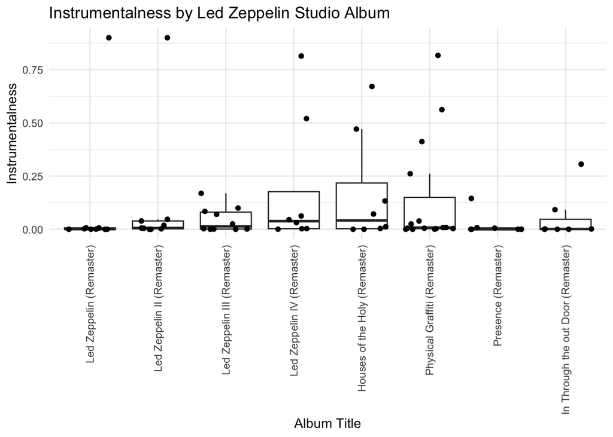

```r
zeppelin0$album_name <- fct_relevel(zeppelin0$album_name, "Led Zeppelin (Remaster)" , "Led Zeppelin II (Remaster)", "Led Zeppelin III (Remaster)",
              "Led Zeppelin IV (Remaster)", "Houses of the Holy (Remaster)", "Physical Graffiti (Remaster)",
              "Presence (Remaster)", "In Through the out Door (Remaster)")


ggplot(zeppelin0, aes(x = album_name, y = instrumentalness)) +
geom_boxplot(outlier.shape = NA) +
  geom_jitter() +
  theme_minimal() +
  theme(axis.text.x = element_text(angle = 90, vjust = 0.5, hjust=1)) +
  labs(title = 'Instrumentalness by Led Zeppelin Studio Album', x = 'Album Title', y = 'Instrumentalness')
```

Above is a box plot (with jitter representing each individual song) that is displaying the instrumentalness of each album ordered by its release.

`instrumentalness` is a predictor of whether a track contains no vocals. The closer to 1.0, the greater the confidence that the track is an instrumental, and if the score is over .5 the track is likely an instrumental[^2].

There seems to be a change in instrumentalness per Zeppelin album based on the plot. The trend seems to be that the band had the highest instrumentalness in the middle of their career. From my own listening, this makes sense because the band was more of a blues oriented band in their beginning, then moved to more progressive rock elements, such as extensive drum or guitar soloing. It also makes sense that their last two releases have relatively low instrumentalness because these albums incorporated more pop elements, such as synthesizers, and tended to focus less on the musicianship of the band.

Something else that stands out to me here is that the band seems to have at least one mostly instrumental (over .5 instrumentalness) track per album, except in the third and final two albums. Let’s take a closer look.

```r
top_songs <- zeppelin0 %>%
  group_by(album_name) %>%
  filter(instrumentalness == max(instrumentalness)) %>%
  ungroup() %>%
  slice_max(instrumentalness, n = 10) %>%
  select(album_name,
         song_name = track_name,
         max_instrumentalness = instrumentalness,
         Year = album_release_year) %>%
  arrange(-Year)


knitr::kable(top_songs)
```

| album_name | song_name | max_instrumentalness | Year |
| --- | --- | --- | --- |
| In Through the out Door (Remaster) | Carouselambra - Remaster | 0.306 | 1979 |
| Presence (Remaster) | Nobody’s Fault but Mine - Remaster | 0.145 | 1976 |
| Physical Graffiti (Remaster) | Boogie with Stu - Remaster | 0.817 | 1975 |
| Houses of the Holy (Remaster) | No Quarter - Remaster | 0.671 | 1973 |
| Led Zeppelin IV (Remaster) | Four Sticks - Remaster | 0.814 | 1971 |
| Led Zeppelin III (Remaster) | Immigrant Song - Remaster | 0.169 | 1970 |
| Led Zeppelin II (Remaster) | Moby Dick - Remaster | 0.900 | 1969 |
| Led Zeppelin (Remaster) | Black Mountain Side - Remaster | 0.900 | 1969 |

Here, we see the individual tracks per album that have the highest instrumentalness. We see that each of their albums has a mostly instrumental track except Led Zeppelin III and the final two albums. This further supports a difference in the sound album to album, as well as the trend that the earlier and later albums had less instrumental music. Now, let’s run an Anova on album name and instrumentalness.

Null Hypothesis: instrumentalness remains the same across Led Zeppelin’s studio albums.

Alternative Hypothesis: instrumentalness differs bewteen Led Zeppelin’s studio albums.

```r
model <- aov(instrumentalness ~ album_name,
                  data = zeppelin0)
summary(model)
```

```
##             Df Sum Sq Mean Sq F value Pr(>F)
## album_name   7  0.206 0.02941   0.533  0.807
## Residuals   65  3.588 0.05521
```

[^1]: Source: https://towardsdatascience.com/is-my-spotify-music-boring-an-analysis-involving-music-data-and-machine-learning-47550ae931de
[^2]: Source: https://www.theverge.com/tldr/2018/2/5/16974194/spotify-recommendation-algorithm-playlist-hack-nelson